# Simple Linear Regression

Arnab Aich

## Introduction

Simple Linear Regression (SLR) is a statistical method used to model the relationship between two continuous variables. It is often used to predict the value of one variable (the dependent variable) based on the value of another variable (the independent variable). In this context, the **independent variable** (also known as the predictor or explanatory variable) influences or predicts the **dependent variable** (the response variable).

### The Linear Equation

The equation for Simple Linear Regression is:

$$y = \beta_0 + \beta_1 x$$

where:

1. **Intercept ($\beta_0$)**: The value of $y$ when the variable $x$ is 0. It represents the starting point of the regression line on the y-axis.
2. **Slope ($\beta_1$)**: The amount by which $y$ is expected to change for each one-unit increase in $x$. If the slope is positive, it indicates a positive relationship between the variables; if it is negative, it indicates a negative relationship.

### Data Visualization

The dataset we will use for this example is the `mtcars` dataset, which contains information about various car models, including miles per gallon (`mpg`), weight (`wt`) in 1000lbs, and other attributes.

| MPG | Weight | MPG | Weight | MPG | Weight | MPG | Weight |
| --- | --- | --- | --- | --- | --- | --- | --- |
| 21.0 | 2.620 | 22.8 | 3.150 | 14.7 | 5.345 | 19.2 | 3.845 |
| 21.0 | 2.875 | 19.2 | 3.440 | 32.4 | 2.200 | 27.3 | 1.935 |
| 22.8 | 2.320 | 17.8 | 3.440 | 30.4 | 1.615 | 26.0 | 2.140 |
| 21.4 | 3.215 | 16.4 | 4.070 | 33.9 | 1.835 | 30.4 | 1.513 |
| 18.7 | 3.440 | 17.3 | 3.730 | 21.5 | 2.465 | 15.8 | 3.170 |
| 18.1 | 3.460 | 15.2 | 3.780 | 15.5 | 3.520 | 19.7 | 2.770 |
| 14.3 | 3.570 | 10.4 | 5.250 | 15.2 | 3.435 | 15.0 | 3.570 |
| 24.4 | 3.190 | 10.4 | 5.424 | 13.3 | 3.840 | 21.4 | 2.780 |

Before we perform any regression analysis, it’s a good practice to visualize the data. This helps us understand the relationship between the independent and dependent variables. A scatter plot is constructed by plotting individual pair of data points of the dependent variable on the y-axis and the independent variable on the x-axis. Below, we will create a scatter plot to visualize the relationship between `mpg` (miles per gallon) and `wt` (weight of the car) from the `mtcars` dataset.

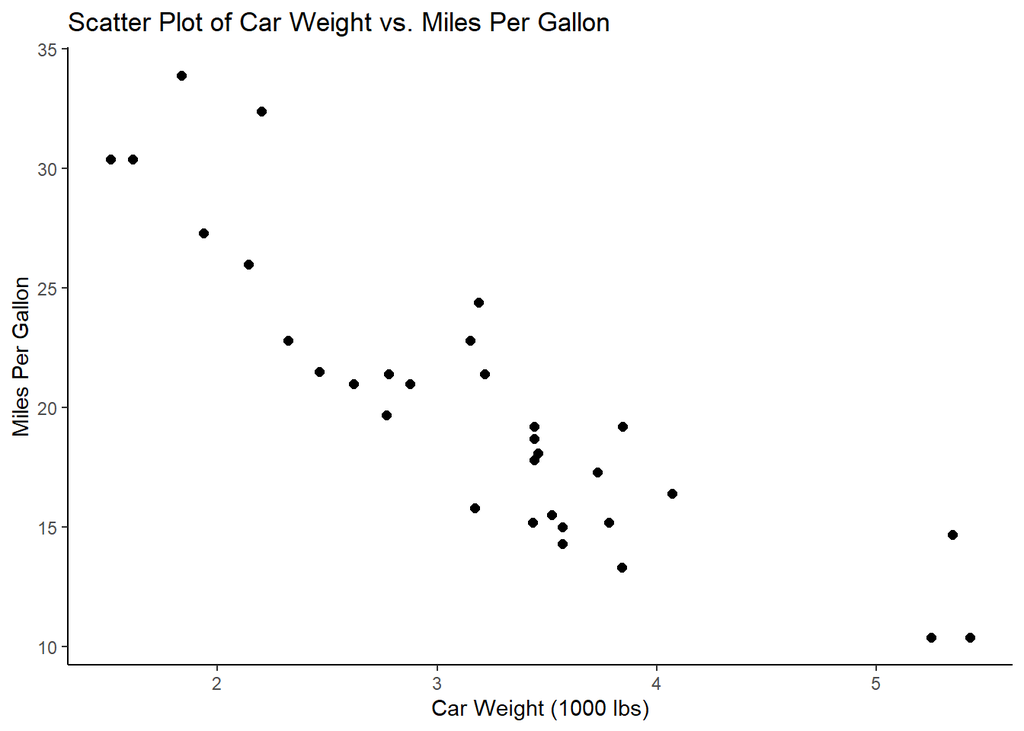

## Simple Linear Regression

The main idea behind SLR is to find the best-fitting line through the data points that minimizes the sum of the squared differences between the observed values and the values predicted by the model. This method is known as “Least Squares Estimation”.

### Correlation Coeficient ($r$)

Correlation coefficient measures the strength and direction of the **linear relationship** between two variables. The formula for Pearson’s correlation coefficient ($r$) is:

$$r = \frac{\text{Cov}(X, Y)}{\sigma_X \sigma_Y} = \frac{\sum_{i =
1}^n\sum_{j=1}^n (x_i - \bar{x})(y_j - \bar{y})}{\sqrt{\sum_{i=1}^n (x_i
- \bar{x})^2}\sqrt{\sum_{j=1}^n (y_j - \bar{y})^2}}$$

where:

- $\text{Cov}(X, Y)$ is the covariance of $X$ and $Y$,
- $\sigma_X$ and $\sigma_Y$ are the standard deviations of $X$ and $Y$.
- $\bar{x}$ and $\bar{y}$ are the means of $X$ and $Y$, respectively.
- $n$ is the number of observations.

#### Properties:

1. $r$ ranges from -1 to 1.
2. $r = 1$ indicates a perfect positive correlation.
3. $r = -1$ indicates a perfect negative correlation.
4. $r = 0$ suggests no linear relationship.

#### Different Types of Correlation

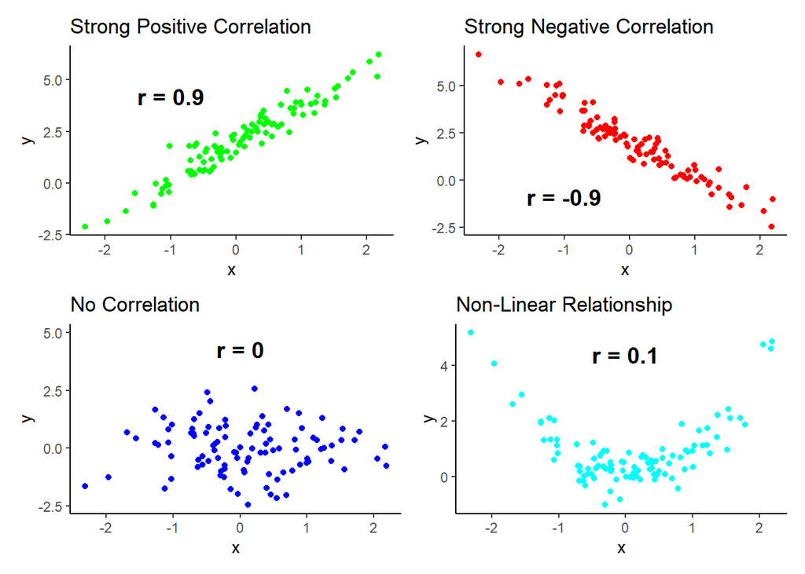

#### Correlation vs. Causation

Correlation measures the strength and direction of the linear relationship between two variables. However, it’s crucial to understand that **correlation does not imply causation**. Just because two variables are correlated does not mean that changes in one variable cause changes in the other.

**Example:** Ice Cream Sales and Drowning Incidents

- **Observation**: You may find that ice cream sales and drowning incidents are positively correlated. That is, on days when more ice cream is sold, there are also more cases of drowning reported.
- **Misinterpretation**: One might incorrectly assume that eating ice cream causes people to drown.
- **True Reason**: Both variables are influenced by a third factor — hot weather. During summer, people tend to buy more ice cream and also spend more time swimming, which may lead to more incidents of drowning.

To visualize this concept, let’s make a scatter plot of two variables that are correlated but have no direct causation.

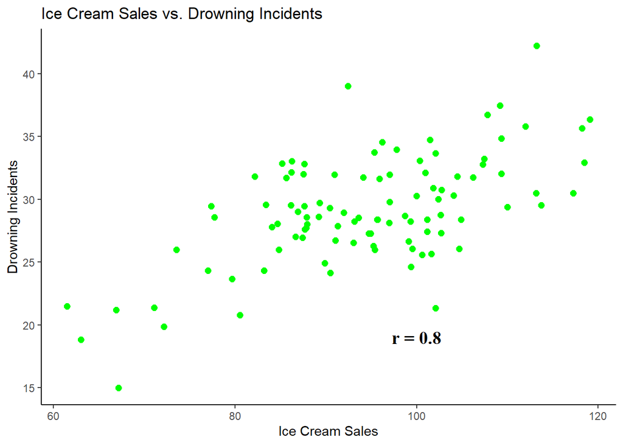

This example illustrates that while two variables can be correlated, it doesn’t mean one causes the other. Always look for potential third variables (confounding factors) before concluding a causal relationship.

### Mathematical Model

The mathematical model for Simple Linear Regression can be described as:

$$y = \beta_0 + \beta_1 x + \epsilon$$

where:

- $y$ is the dependent variable (response variable) and $x$ is the independent variable (predictor).
- $\epsilon$ is the error term(residuals), which captures the deviation of observed values from the predicted line.

The goal is to find values of $\beta_0$ and $\beta_1$ that minimize the sum of squared errors (differences between actual and predicted values). Using the `mtcars` dataset, where `mpg` is the dependent variable and `wt` is the independent variable:

- **Intercept ($\beta_0$)**: Represents the expected `mpg` when the car’s weight is 0 (not always practical but helps to position the line).
- **Slope ($\beta_1$)**: Tells us how much the `mpg` changes for a one-unit increase in `wt`. If it’s negative, it means heavier cars tend to have lower `mpg`.

### Assumptions

For Simple Linear Regression to provide reliable results, certain assumptions must be met. These assumptions are essential for the model to be valid, and violations can lead to misleading interpretations.

#### 1. Linearity

- **Assumption**: The relationship between the independent variable ($x$) and the dependent variable ($y$) should be linear.
- **Why It Matters**: If the relationship is not linear, the model may not accurately represent the data, leading to incorrect predictions.

#### 2. Independence of Errors

- **Assumption**: The residuals (errors) should be independent of each other.
- **Why It Matters**: Violations of this assumption often occur in time-series data where errors may be correlated over time. This can lead to unreliable estimates of coefficients and standard errors.

#### 3. Homoscedasticity (Constant Variance)

- **Assumption**: The variance of the errors should be constant across all levels of the independent variable.
- **Why It Matters**: If the variance of the errors changes (heteroscedasticity), it can affect the efficiency of the estimates, leading to biased predictions.

#### 4. Normality of Errors

- **Assumption**: The errors should be approximately normally distributed.
- **Why It Matters**: This assumption is particularly important for hypothesis testing. If the errors are not normally distributed, the confidence intervals and significance tests may not be valid.

### Parameter Estimation

In Simple Linear Regression, the goal is to find the best-fitting line through the data points by estimating two parameters:

- **Intercept ($\beta_0$)**: The expected value of the dependent variable ($y$) when the independent variable ($x$) is 0.
- **Slope ($\beta_1$)**: The amount by which $y$ changes for a one-unit change in $x$.

These parameters are estimated using the **Least Squares Method**, which minimizes the sum of the squared differences between the observed values and the predicted values. The sum of squared errors (SSE) is given by:

$$\text{SSE} = \sum_{i=1}^n \hat{\epsilon_i}^2 = \sum_{i=1}^{n} e_i^2 =
\sum_{i=1}^{n} (y_i - \hat{y}_i)^2$$

where:

- $n$ is the number of observations,
- $y_i$ is the $i$th observed value,
- $\hat{y}_i = \hat{\beta}_0 + \hat{\beta_1} x_i$ is the predicted value from the regression model,
- $e_i$ is the error for the $i$th observation (observed residual values).

The goal is to minimize SSE, leading to the best estimates for the slope ($\hat{\beta_1}$) and intercept ($\hat{\beta_0}$). The formulas for these estimates are:

$$\hat{\beta_1} = \frac{\sum (x_i - \bar{x})(y_i - \bar{y})}{\sum (x_i -
\bar{x})^2} = -5.34$$

$$\hat{\beta_0} = \bar{y} - \hat{\beta_1}\bar{x} = 20.1 + (5.34 \times
3.22 )= 37.29$$

where:

- $\hat{\beta_1}$ is the estimated slope,
- $\hat{\beta_0}$ is the estimated intercept,
- $\bar{x}$ and $\bar{y}$ are the means of the independent and dependent variables, respectively. The best fitted regression lines passes through the point $(\bar{x}, \bar{y})$.

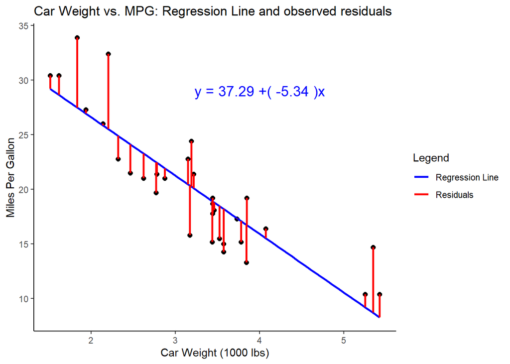

### Residual Analysis

A **Residual vs. Fitted Plot** is a diagnostic tool used to check the assumptions of a linear regression model. Residuals represent the difference between the observed values and the values predicted by the model.

#### Calculation of Fitted Values and Residuals

1. **Fitted Values ($\hat{y}_i$)**: The fitted values are the predictions made by the regression model. They are calculated using the regression equation:
   $$\hat{y}_i = \hat{\beta_0} + \hat{\beta_1}x_i$$
   where:
   - $\hat{\beta_0}$ is the estimated intercept,
   - $\hat{\beta_1}$ is the estimated slope,
   - $x_i$ is the independent variable.

In the `mtcars` dataset, the predicted `mpg` value for a given `wt` can be calculated using the linear model. The fitted `mpg` for `wt`= 2.62 can be calculated as:
$$\hat{y_1} = 37.29 +
(-5.34)\times 2.62 = 23.$$

2. **Residuals ($e_i$)**: The residuals are the differences between the observed values and the fitted values:
   $$e_i = y_i - \hat{y}_i$$
   The observed residual for 1st observation is given as
   $$e_1 =y_1-\hat{y}_1 = 21 - 23 = -2.$$

#### Interpretation:

By plotting the residuals on the y-axis against the fitted values on the x-axis, we can examine patterns that might indicate issues with the model assumptions.

1. **Random Scatter**: If the residuals are randomly scattered around the horizontal axis (y = 0 line), this suggests that the linear model is appropriate, and the assumptions of homoscedasticity and linearity are likely met. Below is an example plot showing a Residual vs. Fitted plot using the `mtcars` dataset:

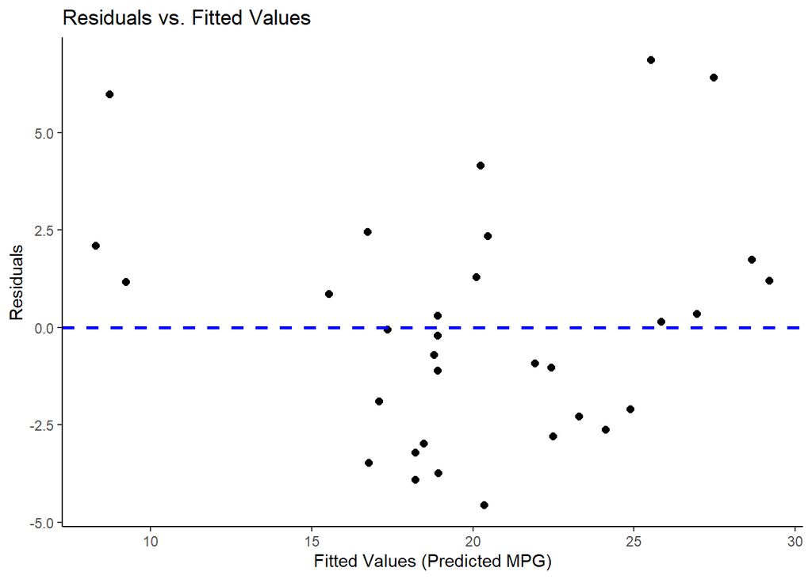

2. **Non-Linear Patterns**: If there is a clear pattern (such as a curve or trend) in the residuals, this might indicate that a linear model is not suitable, and a different type of relationship exists between the variables.

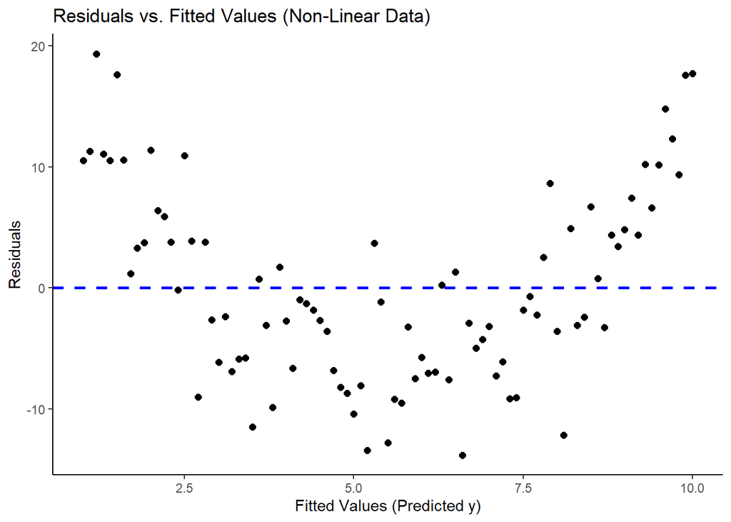

3. **Heteroscedasticity**: If the residuals show a “funnel” shape (i.e., the spread increases or decreases as the fitted values change), this indicates heteroscedasticity, meaning the variance of the errors is not constant across all levels of the independent variable.

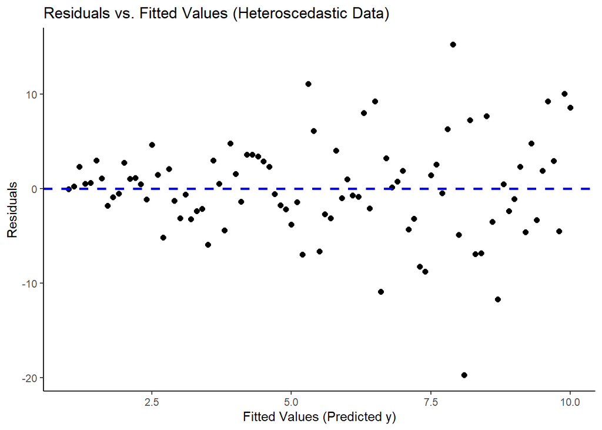

### Coefficient of Determination ($R^2$)

The **Coefficient of Determination**, denoted as $R^2$, measures the proportion of variance in the dependent variable that is predictable from the independent variable(s). In simpler terms, it tells us how well the regression line fits the data.

#### Formula:

The formula for $R^2$ is given by

$$R^2 = \frac{\text{Var}(\hat{Y})}{\text{Var}(Y)} = \frac{\sum_{i=1}^n
(\hat{y}_i - \bar{y})^2}{\sum_{i=1}^n (y_i - \bar{y})^2} = \text{cor}(Y,
\hat{Y})^2$$

where:

- $y_i$ is the observed value,
- $\hat{y}_i$ is the fitted (predicted) value,
- $\bar{y}$ is the mean of the observed values,
- $n$ is the number of observations.

#### Interpretation:

1. **$R^2 = 0$**: The model explains none of the variability in the response variable.
2. **$R^2 = 1$**: The model explains all the variability in the response variable.
3. **0 < $R^2$ < 1**: A higher $R^2$ value indicates a better fit, suggesting that the model is explaining more of the variance in the dependent variable, since

$$Var(\hat{Y}) = R^2 \times Var(Y)
.$$

However, a high $R^2$ does not necessarily mean the model is good, as it can still suffer from overfitting or other issues. 4. In simple linear regression, $R^2$ is equal to the square of the correlation coefficient ($r$) between the independent and dependent variables so it always takes a positive value unlike the correlation coefficient.

In our regression model using the `mtcars` dataset, the $R^2$ value = 0.75. This means that approximately 75% of the variability in `mpg` can be explained by `wt`, suggesting a strong linear relationship between car weight and miles per gallon.

## Recap

In this document, we covered the fundamental concepts of **Simple Linear Regression (SLR)**, including:

1. **Introduction to SLR**: We discussed the linear relationship between two continuous variables where one serves as the predictor (independent variable) and the other as the response (dependent variable). The linear equation, $y = \beta_0 + \beta_1 x$, was explained along with the interpretation of intercept and slope.
2. **Data Visualization**: We used the `mtcars` dataset to understand the relationship between `mpg` (miles per gallon) and `wt` (weight of the car). The scatter plot showed the distribution of data points, helping us to visualize the association between the two variables.
3. **Correlation Coefficient**: We introduced the Pearson correlation coefficient $r$, which measures the strength and direction of a linear relationship between two variables. We also discussed different types of correlations and clarified that **correlation does not imply causation**.
4. **Mathematical Model**: The linear regression equation was presented, and we explored the method of estimating parameters using the **Least Squares Method**. We explained the concepts of **fitted values** and **residuals**, and how these are used to minimize the error in the model.
5. **Assumptions**: We outlined the key assumptions of Simple Linear Regression, including linearity, independence of errors, homoscedasticity, and normality of errors. Understanding these assumptions helps ensure the reliability of the regression model.
6. **Residual vs. Fitted Plot**: This diagnostic tool helps check the assumptions of the model. We looked at examples showing random scatter, non-linear patterns, and heteroscedasticity to understand how to interpret residual plots.
7. **Coefficient of Determination ($R^2$)**: We explained $R^2$, which measures the proportion of variance explained by the model, and provided an interpretation of different $R^2$ values. We emphasized that $R^2$ is not always an indicator of a good model, as other diagnostics and context must also be considered.

By the end of this document, you should have a solid understanding of Simple Linear Regression, how to fit a model using real data, interpret the results, and validate the assumptions to ensure your model is reliable. Always make sure to visualize your data, check the assumptions, and consider multiple diagnostics before making any conclusions from your regression analysis.

## Q&A Section

**Q1: What is Simple Linear Regression (SLR)?** - **Answer**: Simple Linear Regression is a statistical method used to model the linear relationship between two continuous variables, where one variable acts as the predictor (independent) and the other as the response (dependent). It helps in predicting the dependent variable based on the value of the independent variable.

**Q2: How do you interpret the slope ($\beta_1$) in a Simple Linear Regression model?** - **Answer**: The slope represents the expected change in the dependent variable ($y$) for a one-unit increase in the independent variable ($x$). If the slope is positive, it indicates a positive relationship; if it is negative, it suggests a negative relationship between the variables.

**Q3: What is the purpose of a residual vs. fitted plot?** - **Answer**: A residual vs. fitted plot is used to check the assumptions of a linear regression model. It helps identify if there are patterns in the residuals that indicate problems like non-linearity, heteroscedasticity, or issues with independence.

**Q4: Why is it important to check the assumptions of Simple Linear Regression?** - **Answer**: Checking the assumptions is crucial because violations can lead to misleading or incorrect interpretations of the regression results. For example, non-linearity or heteroscedasticity can affect the accuracy of the model’s predictions and standard errors.

**Q5: Can the correlation coefficient $r$ be negative? What does it signify?** - **Answer**: Yes, the correlation coefficient $r$ can be negative, indicating a negative linear relationship between the two variables. A negative $r$ means that as one variable increases, the other tends to decrease.

**Q6: Explain why correlation does not imply causation with an example.** - **Answer**: Correlation does not imply causation because two variables can be correlated due to a third factor, or purely by coincidence. For example, ice cream sales and drowning incidents might be positively correlated, but it does not mean ice cream consumption causes drowning. Both increase during hot weather, which is the third variable influencing them.

**Q7: How is the coefficient of determination ($R^2$) related to the correlation coefficient $r$?** - **Answer**: In Simple Linear Regression, $R^2$ is equal to the square of the correlation coefficient $r$. Therefore, if $r$ is positive or negative, $R^2$ will always be a positive value representing the proportion of variance in the dependent variable explained by the independent variable.

**Q8: What does an $R^2$ value of 0.85 mean?** - **Answer**: An $R^2$ value of 0.85 indicates that 85% of the variability in the dependent variable can be explained by the independent variable. It suggests a strong linear relationship between the two variables.

**Q9: How can you calculate the residual for an observation in the dataset?** - **Answer**: The residual is the difference between the observed value and the predicted (fitted) value from the regression model. Mathematically, $e_i = y_i - \hat{y}_i$, where $y_i$ is the observed value, and $\hat{y}_i$ is the fitted value.

**Q10: What is the equation for predicting the dependent variable using the Simple Linear Regression model?** - **Answer**: The equation is $\hat{y} = \beta_0 + \beta_1 x$, where $\hat{y}$ is the predicted value, $\beta_0$ is the intercept, and $\beta_1$ is the slope. You can use this equation to estimate the dependent variable based on the value of the independent variable.